# New topics in network modeling

## 0.1 Overview

- With **more data** and **computing resources**, the things that we can ask and do with networks are becoming increasingly (even more) exciting and complex.
- In this section, I will introduce **some** of the latest advancements and forthcoming topics in network modeling.

# 1 Part I: New models and extensions

## 1.1 Mutli-ERGMs

- In Krivitsky, Coletti, and Hens (2023a), the authors present a start-to-finish pooled ERGM example featuring heterogeneous data sources.
- They increase power and allow exploring heterogeneous effects across types/classes of networks.

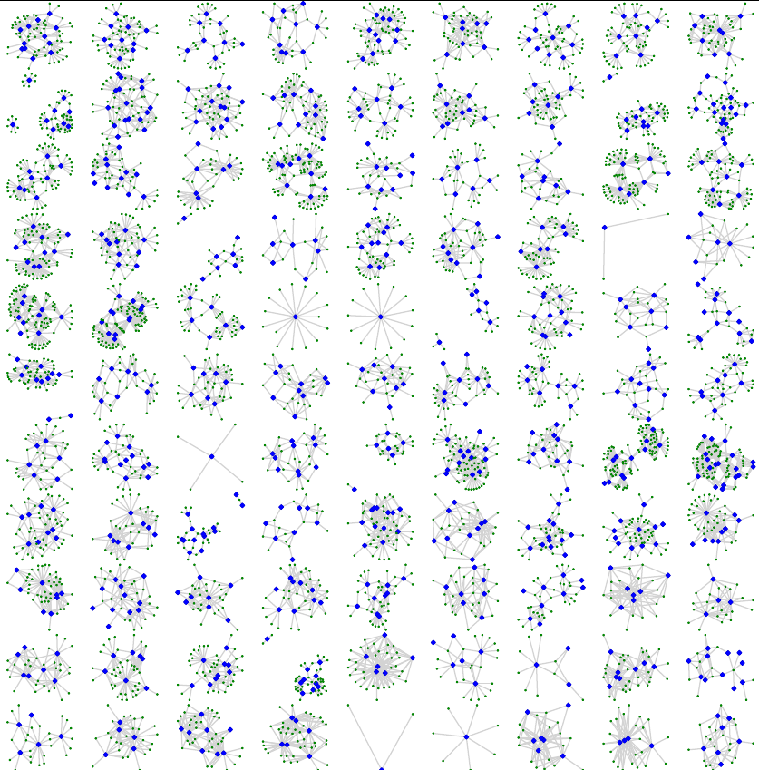

## 1.2 Statistical power of SOAM

- **SOAM** Stadtfeld et al. (2020) proposes ways to perform power analysis for Siena models. At the center of their six-step approach is simulation.

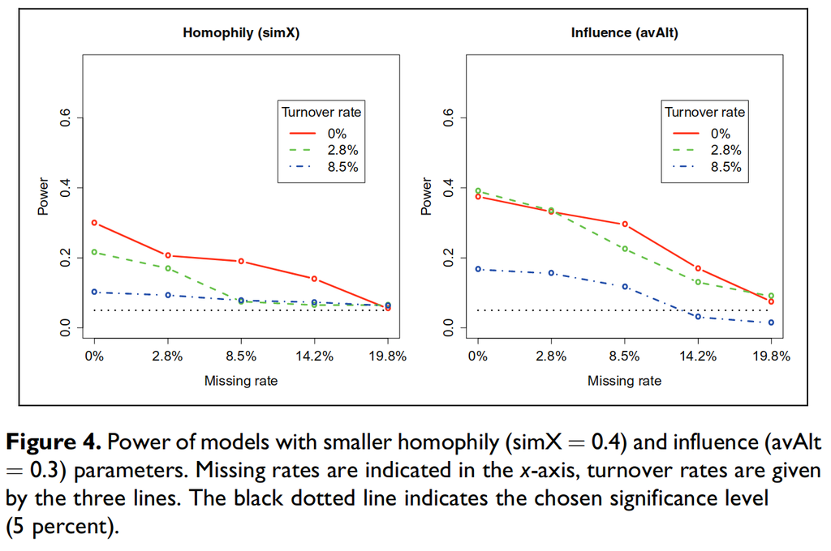

## 1.3 Bayesian ALAAM

Ever wondered how to model influence exclusively?

- The Auto-Logistic Actor Attribute Model [ALAAM] is a model that allows us to do just that.
- Koskinen and Daraganova (2022) extends the ALAAM model to a Bayesian framework.
- It provides greater flexibility to accommodate more complicated models and add extensions such as hierarchical models.

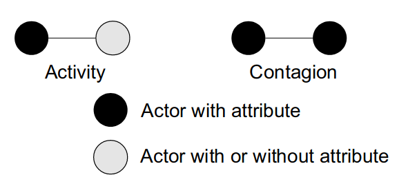

## 1.4 Relational Event Models

- REMs are great for modeling sequences of ties (instead of panel or cross-sectional.)
- Butts et al. (2023) provides a general overview of Relational Event Models [REMs,] new methods, and future steps.

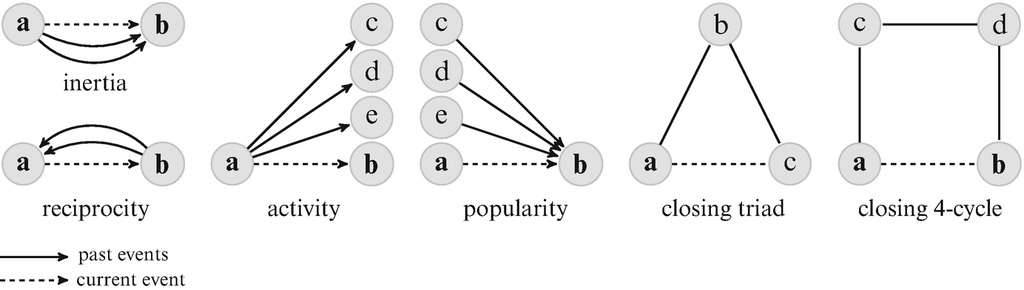

Figure 3 reproduced from Brandenberger (2020)

## 1.5 Big ERGMs

- **ERGMs** In A. Stivala, Robins, and Lomi (2020), a new method is proposed to estimate large ERGMs (featuring millions of nodes).

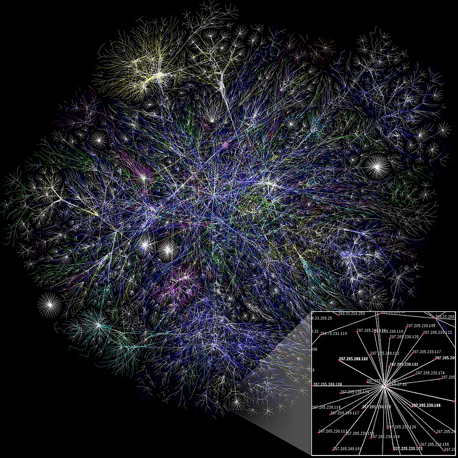

Partial map of the Internet based on the January 15, 2005 data found on opte.org. – [Wiki](https://en.wikipedia.org/w/index.php?title=File:Internet_map_1024.jpg&oldid=1061830697)

## 1.6 Exponential Random *Network* Models

- Wang, Fellows, and Handcock recently published a re-introduction of the ERNM framework (Wang, Fellows, and Handcock 2023).
- ERNMs generalize ERGMs to incorporate behavior and are the cross-sectional causing of SIENA models.

$$\begin{align*}
\text{ER\textbf{G}M}: & P_{\mathcal{Y}, \bm{\theta}}(\bm{Y}=\bm{y} | \bm{X}=\bm{x}) \\
\text{ER\textbf{N}M}: & P_{\mathcal{Y}, \bm{\theta}}(\bm{Y}=\bm{y}, \bm{X}=\bm{x})
\end{align*}$$

# 2 Part II: Shameless self-promotion

## 2.1 ERGMitos: Small ERGMs

- **ERGMitos**[^1] (Vega Yon, Slaughter, and Haye 2021) leverage small network sizes to use exact statistics.

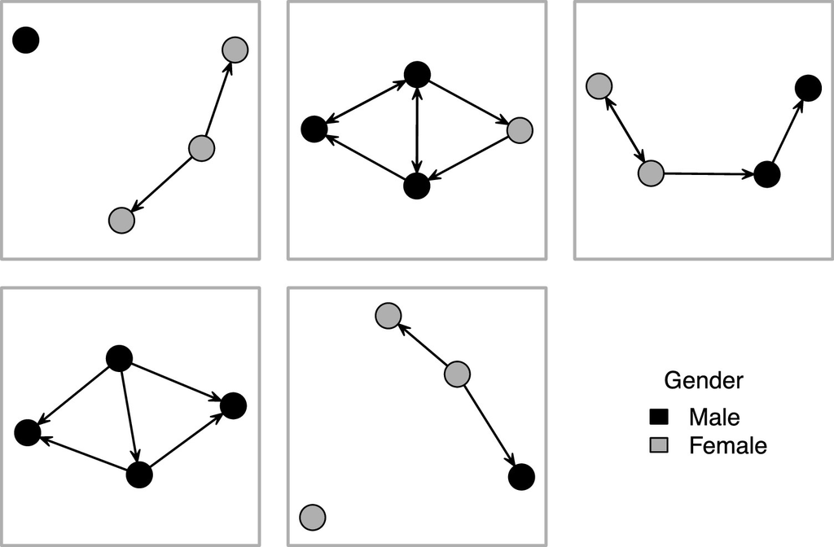

Five small networks from the `ergmito` R package

## 2.2 Discrete Exponential-family Models

- ERGMs are a particular case of Random Markov fields.
- We can use the ERGM framework for modeling vectors of binary outcomes, e.g., the consumption of $\{tobacco, MJ, alcohol\}$

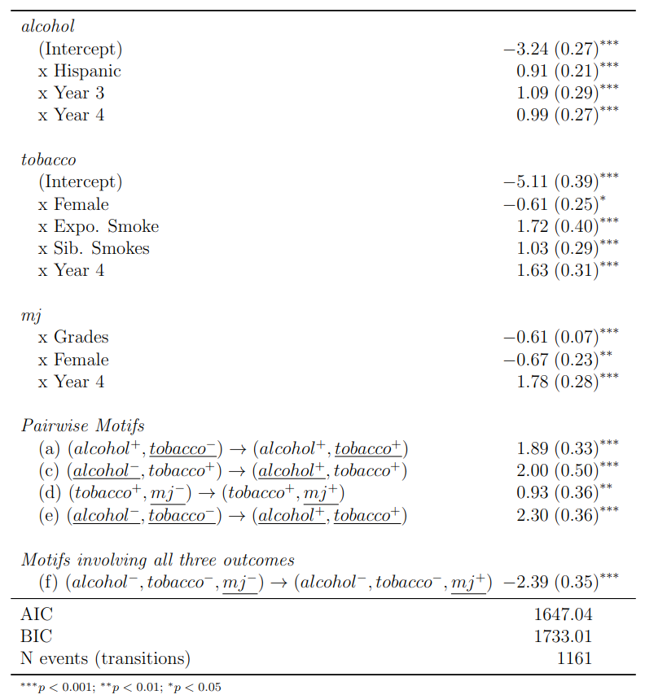

## 2.3 Power analysis in ERGMs

- Using conditional ERGMs (closely related to constrained), we can do power analysis for network samples (Vega Yon 2023).

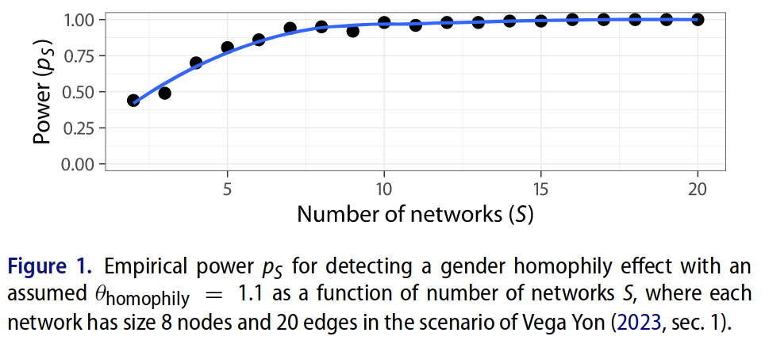

Reproduced from Krivitsky, Coletti, and Hens (2023b)

## 2.4 Two-step estimation ERGMs

- Conditioning the ERGM on an observed statistic “drops” the associated coefficient.
- Hypothesis: As $n$ increases, conditional ERGM estimates are consistent with the full model:

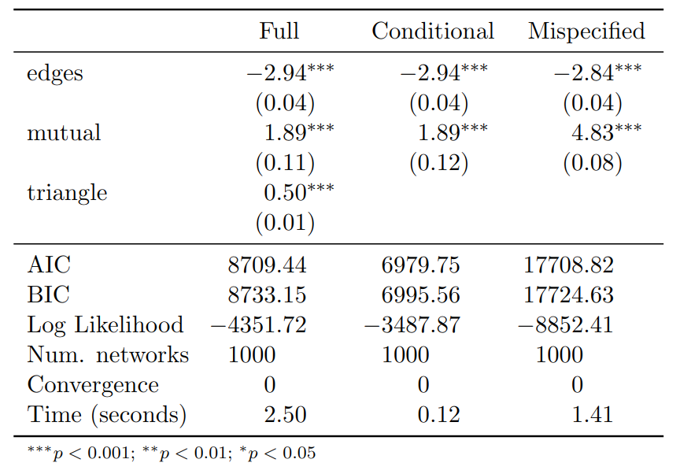

Simulation study trying to demonstrate the concept (Work in progress)

## 2.5 Thanks!

## 2.6 Bonus track: Why network scientists don’t use ERGMs?

> Attempts to overcome these problems by extending the blockmodel have focused particularly on the use of (more complicated) p∗ or exponential random graph models, but **while these are conceptually appealing**, they quickly **lose the analytic tractability** of the original blockmodel **as their complexity increases**.

> – Karrer and Newman (2011)

## 2.7 References

Brandenberger, Laurence. 2020. “Interdependencies in Conflict Dynamics: Analyzing Endogenous Patterns in Conflict Event Data Using Relational Event Models.” In *Computational Conflict Research*, edited by Emanuel Deutschmann, Jan Lorenz, Luis G. Nardin, Davide Natalini, and Adalbert F. X. Wilhelm, 67–80. Computational Social Sciences. Cham: Springer International Publishing. https://doi.org/10.1007/978-3-030-29333-8_4.

Butts, Carter T., Alessandro Lomi, Tom A. B. Snijders, and Christoph Stadtfeld. 2023. “Relational Event Models in Network Science.” *Network Science* 11 (2): 175–83. https://doi.org/10.1017/nws.2023.9.

Karrer, Brian, and M. E. J. Newman. 2011. “Stochastic Blockmodels and Community Structure in Networks.” *Physical Review E* 83 (1): 016107. https://doi.org/10.1103/PhysRevE.83.016107.

Koskinen, Johan, and Galina Daraganova. 2022. “Bayesian Analysis of Social Influence.” *Journal of the Royal Statistical Society Series A: Statistics in Society* 185 (4): 1855–81. https://doi.org/10.1111/rssa.12844.

Krivitsky, Pavel N., Pietro Coletti, and Niel Hens. 2023a. “A Tale of Two Datasets: Representativeness and Generalisability of Inference for Samples of Networks.” *Journal of the American Statistical Association* 0 (0): 1–21. https://doi.org/10.1080/01621459.2023.2242627.

———. 2023b. “Rejoinder to Discussion of ‘A Tale of Two Datasets: Representativeness and Generalisability of Inference for Samples of Networks’.” *Journal of the American Statistical Association* 118 (544): 2235–38. https://doi.org/10.1080/01621459.2023.2280383.

Stadtfeld, Christoph, Tom A. B. Snijders, Christian Steglich, and Marijtje van Duijn. 2020. “Statistical Power in Longitudinal Network Studies.” *Sociological Methods & Research* 49 (4): 1103–32. https://doi.org/10.1177/0049124118769113.

Stivala, Alex D., H. Colin Gallagher, David A. Rolls, Peng Wang, and Garry L. Robins. 2020. “Using Sampled Network Data With The Autologistic Actor Attribute Model.” arXiv. https://doi.org/10.48550/arXiv.2002.00849.

Stivala, Alex, Garry Robins, and Alessandro Lomi. 2020. “Exponential Random Graph Model Parameter Estimation for Very Large Directed Networks.” *PLoS ONE* 15 (1): 1–23. https://doi.org/10.1371/journal.pone.0227804.

Vega Yon, George G. 2023. “Power and Multicollinearity in Small Networks: A Discussion of ‘Tale of Two Datasets: Representativeness and Generalisability of Inference for Samples of Networks’ by Krivitsky, Coletti & Hens.” *Journal Of The American Statistical Association*.

Vega Yon, George G., Andrew Slaughter, and Kayla de la Haye. 2021. “Exponential Random Graph Models for Little Networks.” *Social Networks* 64 (August 2020): 225–38. https://doi.org/10.1016/j.socnet.2020.07.005.

Wang, Zeyi, Ian E. Fellows, and Mark S. Handcock. 2023. “Understanding Networks with Exponential-Family Random Network Models.” *Social Networks*, August, S0378873323000497. https://doi.org/10.1016/j.socnet.2023.07.003.

## Footnotes

[^1]: From the Spanish suffix meaning small.